# Practical machine learning

2023-10-02

# Overview

The goal is to use data from accelerometers on the belt, forearm, arm, and dumbell of 6 participants. They were asked to perform barbell lifts correctly and incorrectly in 5 different ways (classe A to E). “Six young health participants were asked to perform one set of 10 repetitions of the Unilateral Dumbbell Biceps Curl in five different fashions: exactly according to the specification (Class A), throwing the elbows to the front (Class B), lifting the dumbbell only halfway (Class C), lowering the dumbbell only halfway (Class D) and throwing the hips to the front (Class E).” (Read more: http:/groupware.les.inf.puc-rio.br/har#ixzz4TphcNzin)

In section “Loading and cleaning” we load and pre-process the data, to remove the “NA” and variables “trivially correlated” such as the index (“X”), or the time (See Fig. 1, in the Appendix). In the section “Model” we train our model, using a random forest (without principal component analysis). We used 80% of the observations for training and the remaining 20% for testing. In section “Prediction” we predict the values for the “testing data” provided in this exercise.

## Loading and cleaning

```r
data <- read.csv("/home/paula/Documents/DATA_SCIENCE/practical_ML/project/pml-training.csv")
dim(data)
```

```
## [1] 19622   160
```

```r
data$classe<-as.factor(data$classe)

set.seed(23457)
inTrain<-createDataPartition(y=data$classe,p=0.8,list=FALSE)
training<-data[inTrain,]
testing<-data[-inTrain,]
```

```r
accur<-function(values,prediction){confusionMatrix(values$classe, prediction)}
```

```r
Y<- c()
for (i in c(1:length(names(training)))) {
    X<-(is.na(as.numeric(training[,i])))
    Y[i]<-(dim(training[X,])[1]==0)
}
    Clean_training<-training[,Y]
    #removing un-meaningful variables
    Final_training<-Clean_training[,c(5:dim(Clean_training)[2])]
    dim(Final_training)
```

```
## [1] 15699    53
```

```r
    names(Final_training)
```

```
##  [1] "roll_belt"            "pitch_belt"           "yaw_belt"
##  [4] "total_accel_belt"     "gyros_belt_x"         "gyros_belt_y"
##  [7] "gyros_belt_z"         "accel_belt_x"         "accel_belt_y"
## [10] "accel_belt_z"         "magnet_belt_x"        "magnet_belt_y"
## [13] "magnet_belt_z"        "roll_arm"             "pitch_arm"
## [16] "yaw_arm"              "total_accel_arm"      "gyros_arm_x"
## [19] "gyros_arm_y"          "gyros_arm_z"          "accel_arm_x"
## [22] "accel_arm_y"          "accel_arm_z"          "magnet_arm_x"
## [25] "magnet_arm_y"         "magnet_arm_z"         "roll_dumbbell"
## [28] "pitch_dumbbell"       "yaw_dumbbell"         "total_accel_dumbbell"
## [31] "gyros_dumbbell_x"     "gyros_dumbbell_y"     "gyros_dumbbell_z"
## [34] "accel_dumbbell_x"     "accel_dumbbell_y"     "accel_dumbbell_z"
## [37] "magnet_dumbbell_x"    "magnet_dumbbell_y"    "magnet_dumbbell_z"
## [40] "roll_forearm"         "pitch_forearm"        "yaw_forearm"
## [43] "total_accel_forearm"  "gyros_forearm_x"      "gyros_forearm_y"
## [46] "gyros_forearm_z"      "accel_forearm_x"      "accel_forearm_y"
## [49] "accel_forearm_z"      "magnet_forearm_x"     "magnet_forearm_y"
## [52] "magnet_forearm_z"     "classe"
```

repeating the pre-processing for the testing set

```r
Clean_testing<-testing[,Y]
Final_testing<-Clean_testing[,c(5:dim(Clean_training)[2])]
```

## Model: using a random forest (without principal component analysis)

```r
FIT_final <-train(classe~. , data=Final_training,   method="rf")
```

```r
Predict_final    <-predict(FIT_final , Final_testing)
```

```r
accur(Final_testing,Predict_final  )$overall[1]
```

```
##  Accuracy
## 0.9959215
```

# Prediction: Predicting values in the test set provided

```r
test_data <- read.csv("/home/paula/Documents/DATA_SCIENCE/practical_ML/project/pml-testing.csv")
predict_values<-predict(FIT_final, test_data)
predict_values
```

```
##  [1] B A B A A E D B A A B C B A E E A B B B
## Levels: A B C D E
```

# Apendix 1 pre-analyising the data

```r
names(data)
```

```
##   [1] "X"                        "user_name"
##   [3] "raw_timestamp_part_1"     "raw_timestamp_part_2"
##   [5] "cvtd_timestamp"           "new_window"
##   [7] "num_window"               "roll_belt"
##   [9] "pitch_belt"               "yaw_belt"
##  [11] "total_accel_belt"         "kurtosis_roll_belt"
##  [13] "kurtosis_picth_belt"      "kurtosis_yaw_belt"
##  [15] "skewness_roll_belt"       "skewness_roll_belt.1"
##  [17] "skewness_yaw_belt"        "max_roll_belt"
##  [19] "max_picth_belt"           "max_yaw_belt"
##  [21] "min_roll_belt"            "min_pitch_belt"
##  [23] "min_yaw_belt"             "amplitude_roll_belt"
##  [25] "amplitude_pitch_belt"     "amplitude_yaw_belt"
##  [27] "var_total_accel_belt"     "avg_roll_belt"
##  [29] "stddev_roll_belt"         "var_roll_belt"
```

[output cut: 65 more lines]

```r
head(data$classe)
```

```
## [1] A A A A A A
## Levels: A B C D E
```

```r
Y<- c()
Z<- c()
for (i in c(1:length(names(training)))) {
    X<-(is.na(as.numeric(training[,i]))) #these are the NA values
     # this is the percentage of non NA in each variable
    Z[i]<-(1-(dim(training[X,])[1]/dim(training[,])[1]))*100 # this is the percentage of non NA in each variable
     #This is the vector with the indexes of the variables that are completed
    Y[i]<-(dim(training[X,])[1]==0)
}
Z
```

```
##   [1] 100.000000   0.000000 100.000000 100.000000   0.000000   0.000000
##   [7] 100.000000 100.000000 100.000000 100.000000 100.000000   2.012867
##  [13]   1.904580   0.000000   2.019237   1.904580   0.000000   2.076565
##  [19]   2.076565   2.012867   2.076565   2.076565   2.012867   2.076565
##  [25]   2.076565   2.012867   2.076565   2.076565   2.076565   2.076565
##  [31]   2.076565   2.076565   2.076565   2.076565   2.076565   2.076565
##  [37] 100.000000 100.000000 100.000000 100.000000 100.000000 100.000000
##  [43] 100.000000 100.000000 100.000000 100.000000 100.000000 100.000000
##  [49] 100.000000   2.076565   2.076565   2.076565   2.076565   2.076565
##  [55]   2.076565   2.076565   2.076565   2.076565   2.076565 100.000000
##  [61] 100.000000 100.000000 100.000000 100.000000 100.000000 100.000000
##  [67] 100.000000 100.000000   1.668896   1.662526   2.012867   1.675266
##  [73]   1.662526   2.012867   2.076565   2.076565   2.076565   2.076565
##  [79]   2.076565   2.076565   2.076565   2.076565   2.076565 100.000000
##  [85] 100.000000 100.000000   2.070196   2.070196   0.000000   2.076565
##  [91]   2.076565   0.000000   2.076565   2.076565   2.070196   2.076565
##  [97]   2.076565   2.070196   2.076565   2.076565   2.070196 100.000000
## [103]   2.076565   2.076565   2.076565   2.076565   2.076565   2.076565
## [109]   2.076565   2.076565   2.076565   2.076565 100.000000 100.000000
## [115] 100.000000 100.000000 100.000000 100.000000 100.000000 100.000000
## [121] 100.000000 100.000000 100.000000 100.000000   1.611568   1.605198
## [127]   0.000000   1.617937   1.605198   0.000000   2.076565   2.076565
## [133]   1.611568   2.076565   2.076565   1.611568   2.076565   2.076565
## [139]   1.611568 100.000000   2.076565   2.076565   2.076565   2.076565
## [145]   2.076565   2.076565   2.076565   2.076565   2.076565   2.076565
## [151] 100.000000 100.000000 100.000000 100.000000 100.000000 100.000000
## [157] 100.000000 100.000000 100.000000 100.000000
```

```r
    Clean_training<-training[,Y]
    dim(Clean_training)
```

```
## [1] 15699    57
```

```r
    names(Clean_training)
```

```
##  [1] "X"                    "raw_timestamp_part_1" "raw_timestamp_part_2"
##  [4] "num_window"           "roll_belt"            "pitch_belt"
##  [7] "yaw_belt"             "total_accel_belt"     "gyros_belt_x"
## [10] "gyros_belt_y"         "gyros_belt_z"         "accel_belt_x"
## [13] "accel_belt_y"         "accel_belt_z"         "magnet_belt_x"
## [16] "magnet_belt_y"        "magnet_belt_z"        "roll_arm"
## [19] "pitch_arm"            "yaw_arm"              "total_accel_arm"
## [22] "gyros_arm_x"          "gyros_arm_y"          "gyros_arm_z"
## [25] "accel_arm_x"          "accel_arm_y"          "accel_arm_z"
## [28] "magnet_arm_x"         "magnet_arm_y"         "magnet_arm_z"
## [31] "roll_dumbbell"        "pitch_dumbbell"       "yaw_dumbbell"
## [34] "total_accel_dumbbell" "gyros_dumbbell_x"     "gyros_dumbbell_y"
## [37] "gyros_dumbbell_z"     "accel_dumbbell_x"     "accel_dumbbell_y"
## [40] "accel_dumbbell_z"     "magnet_dumbbell_x"    "magnet_dumbbell_y"
## [43] "magnet_dumbbell_z"    "roll_forearm"         "pitch_forearm"
## [46] "yaw_forearm"          "total_accel_forearm"  "gyros_forearm_x"
## [49] "gyros_forearm_y"      "gyros_forearm_z"      "accel_forearm_x"
## [52] "accel_forearm_y"      "accel_forearm_z"      "magnet_forearm_x"
## [55] "magnet_forearm_y"     "magnet_forearm_z"     "classe"
```

The variables X, raw_timestamp_part_1, raw_timestamp_part_2, num_window are not correlated or has a trivial correlation with “classe” (as the case of X, that is an index), and, therefore, should not be taken into account).

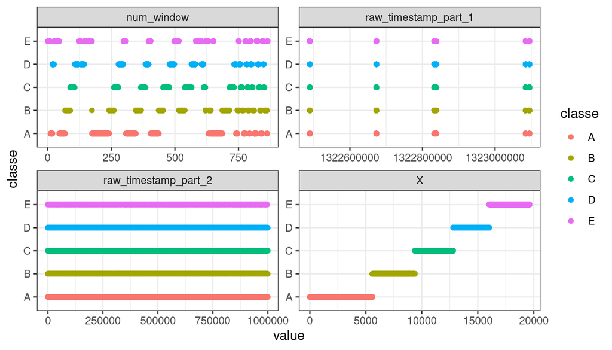

```r
(Clean_training[,c(1:4,dim(Clean_training)[2])]) %>%
  gather(-classe, key = "var", value = "value") %>%
  ggplot(aes(x = value, y = classe, color = classe)) +
    geom_point() +
    facet_wrap(~ var, scales = "free") +
    theme_bw()
```

# Appendix2

### Cross-reference and model selection:

We will use 4 different models with and without principal component “pca” pre-processing. We use cross validation with k-fold (with 10 folds) We will test the Multinomial Log-linear Models “multinom”, regression trees “rpart”, boosting “gbm” and random forest “rf”.

```r
DATA<-Final_training
train_control<- trainControl(method="cv", number=10, savePredictions = TRUE)

#insmall<-createDataPartition(y=Final_training$classe,p=0.2,list=FALSE)
#small_test<-Final_training[insmall,]

#DATA<-small_test
```

With “pca”

```r
FIT_multinorm<-train(classe~. , data=DATA,  preProcess="pca", method="multinom",
                     trControl=train_control, verbose=FALSE, trace=FALSE)
```

```r
FIT_rpart<-train(classe~. , data=DATA,  preProcess="pca", method="rpart",
                 trControl=train_control)
```

```r
FIT_boosting<-train(classe~. , data=DATA,  preProcess="pca", method="gbm",
                    trControl=train_control,verbose=FALSE)
```

```r
FIT_rf<-train(classe~. , data=DATA,  preProcess="pca", method="rf",
              trControl=train_control)
```

Without “pca”

```r
FIT_multinorm2<-train(classe~. , data=DATA,   method="multinom",
                      trControl=train_control, verbose=FALSE, trace=FALSE)
```

```r
FIT_rpart2<-train(classe~. , data=DATA,   method="rpart",
                  trControl=train_control)
```

```r
FIT_boosting2<-train(classe~. , data=DATA,   method="gbm",
                     trControl=train_control,verbose=FALSE)
```

```r
FIT_rf2<-train(classe~. , data=DATA,   method="rf", trControl=train_control)
```

```r
results_training<-data.frame(model=character(), out_the_sample_Error=double())
results_training<-rbind(results_training, data.frame(model="multinorm/pca"
                         ,out_the_sample_Error=mean((FIT_multinorm$resample)[1]$Accuracy) ))
results_training<-rbind(results_training, data.frame(model="rpart/pca"
                         ,out_the_sample_Error=mean((FIT_rpart$resample)[1]$Accuracy)     ))
results_training<-rbind(results_training, data.frame(model="gbm/pca"
                         ,out_the_sample_Error=mean((FIT_boosting$resample)[1]$Accuracy)  ))
results_training<-rbind(results_training, data.frame(model="rf/pca"
                         ,out_the_sample_Error=mean((FIT_rf$resample)[1]$Accuracy)        ))
results_training<-rbind(results_training, data.frame(model="multinorm"
                         ,out_the_sample_Error=mean((FIT_multinorm2$resample)[1]$Accuracy)    ))
results_training<-rbind(results_training, data.frame(model="rpart"
                         ,out_the_sample_Error=mean((FIT_rpart2$resample)[1]$Accuracy)        ))
results_training<-rbind(results_training, data.frame(model="gbm"
                         ,out_the_sample_Error=mean((FIT_boosting2$resample)[1]$Accuracy)     ))
results_training<-rbind(results_training, data.frame(model="rf"
                         ,out_the_sample_Error=mean((FIT_rf2$resample)[1]$Accuracy)           ))
results_training
```

```
##           model out_the_sample_Error
## 1 multinorm/pca            0.5280577
## 2     rpart/pca            0.3596415
## 3       gbm/pca            0.8123461
## 4        rf/pca            0.9772588
## 5     multinorm            0.6679392
## 6         rpart            0.5034705
## 7           gbm            0.9614646
## 8            rf            0.9938208
```

Testing the models in the data set we have:

```r
Predict_multinorm    <-predict(FIT_multinorm , Final_testing)
Predict_rpart        <-predict(FIT_rpart , Final_testing)
Predict_boosting     <-predict(FIT_boosting , Final_testing)
Predict_rf           <-predict(FIT_rf , Final_testing)

Predict_multinorm2   <-predict(FIT_multinorm2, Final_testing)
Predict_rpart2       <-predict(FIT_rpart2 , Final_testing)
Predict_boosting2    <-predict(FIT_boosting2 , Final_testing)
Predict_rf2          <-predict(FIT_rf2 , Final_testing)
```

```r
results_test<-data.frame(model=character(), test_accuracy=double())

results_test<-rbind(results_test,data.frame(model="multinorm/pca"
                  , test_accuracy=accur(Final_testing,Predict_multinorm  )$overall[1]))
results_test<-rbind(results_test,data.frame(model="rpart/pca"
                  , test_accuracy=accur(Final_testing,Predict_rpart      )$overall[1]))
results_test<-rbind(results_test,data.frame(model="gbm/pca"
                  , test_accuracy=accur(Final_testing,Predict_boosting   )$overall[1]))
results_test<-rbind(results_test,data.frame(model="rf/pca"
                  , test_accuracy=accur(Final_testing,Predict_rf         )$overall[1]))
results_test<-rbind(results_test,data.frame(model="multinorm"
                  , test_accuracy=accur(Final_testing,Predict_multinorm2 )$overall[1]))
results_test<-rbind(results_test,data.frame(model="rpart"
                  , test_accuracy=accur(Final_testing,Predict_rpart2     )$overall[1]))
results_test<-rbind(results_test,data.frame(model="gbm"
                  , test_accuracy=accur(Final_testing,Predict_boosting2  )$overall[1]))
results_test<-rbind(results_test,data.frame(model="rf"
                  , test_accuracy=accur(Final_testing,Predict_rf2        )$overall[1]))
results_test
```

```
##                   model test_accuracy
## Accuracy  multinorm/pca     0.5388733
## Accuracy1     rpart/pca     0.3800663
## Accuracy2       gbm/pca     0.8159572
## Accuracy3        rf/pca     0.9811369
## Accuracy4     multinorm     0.6507775
## Accuracy5         rpart     0.4825389
## Accuracy6           gbm     0.9655876
## Accuracy7            rf     0.9961764
```